# word_assoc

### Length of dataframes produced by each “category”

it is import to keep in mind for all results (including here, in wordclouds, and bigram plots) that the number of hits for each query term varies dramatically, with “soil” terms being used far more frequently than “rangeland” or “forest” terms. For this reason, it may not be very valuable to perform this sort of analysis while looking at the most influential tweets. Nevertheless, this it seems valuable to get a feel for the different language being used within each category

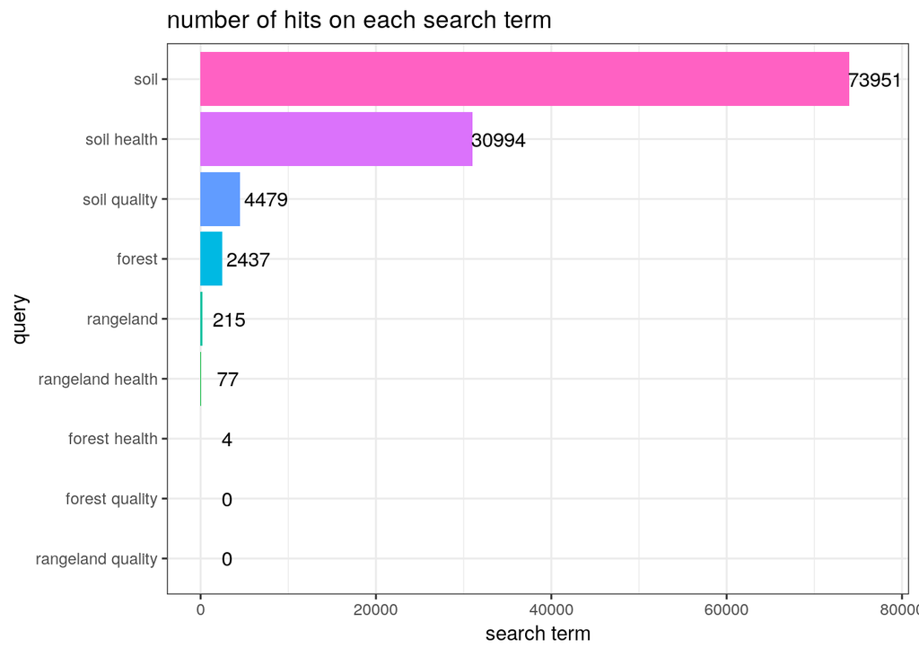

### same as above without ‘soil’ terms

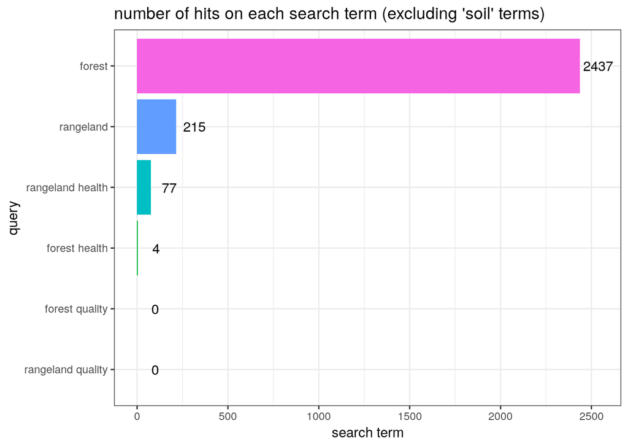

## looking at the relative hits on query terms (i.e those originally used to querry the API)

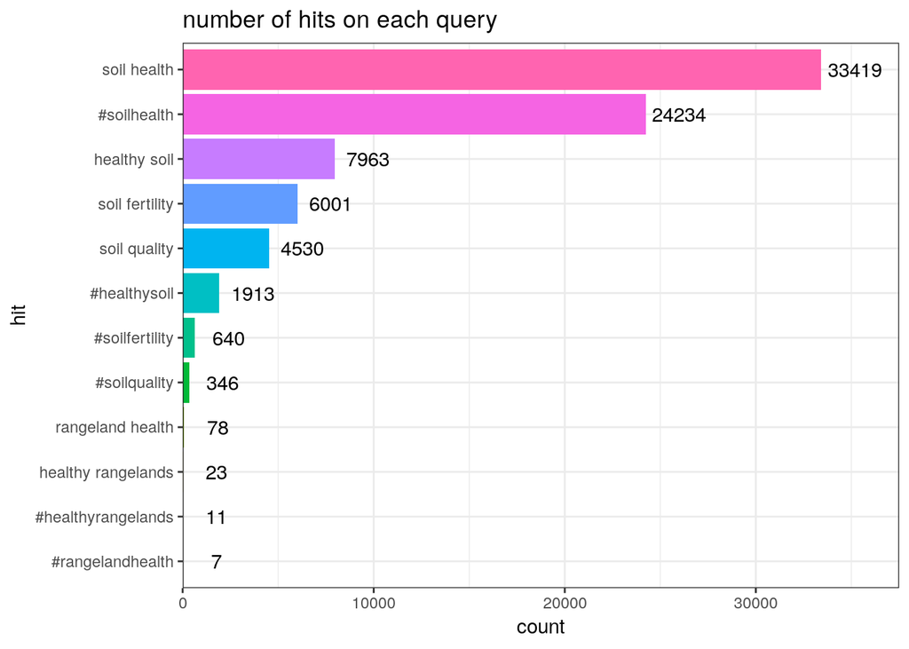

### compare if/how content changes when a tweet contains each group of query terms

##### groupings are:

- soil health = ‘soil health’,‘#soilhealth’,‘healthy soil’,‘#healthysoil’
- soil quality = ‘soil quality’,‘#soilquality’
- soil fertiliy = ‘soil fertility’,‘#soilfertility’
- rangeland = ‘rangeland health’,‘#rangelandhealth’,‘healthy rangelands’,‘#healthyrangelands’

#### caclculate percentages based relative to word counts of top 20

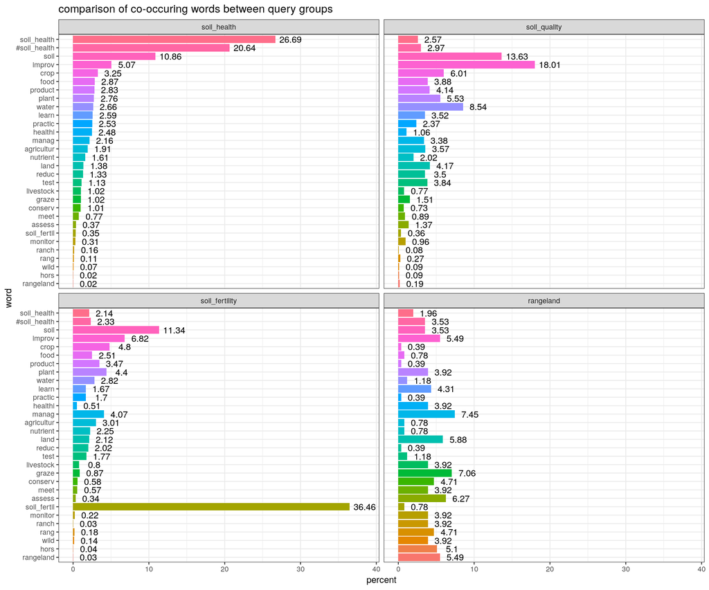

#### caclculate percentages based relative to total word counts of each category

no change in trend, only in percentages

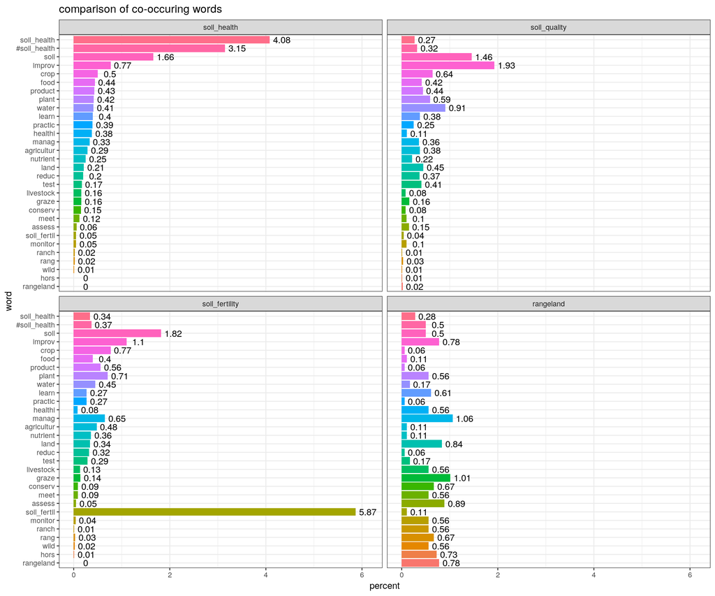

#### same comparison, but visually comparing based on word counts of ‘range’

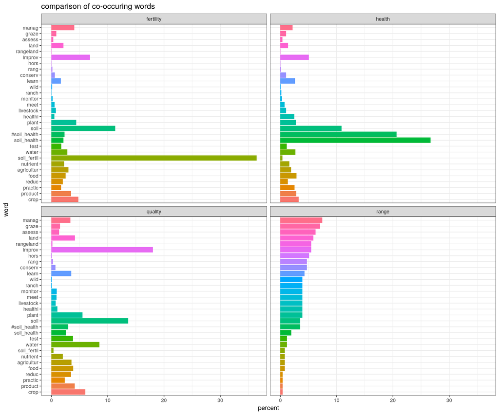

# visualizing propotions

### looking at ‘soil’ terms alone

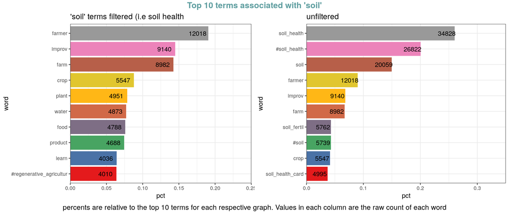

### comparing: soil health, soil qualitly, soil fertility

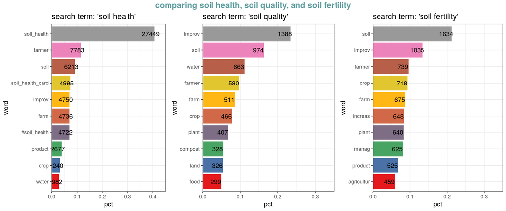

percents are relative to the top terms for each respective graph. Values in each column are the raw count of each word. the terms ‘soil quality’ and ‘soil fertility’ were filtered out of ther respective graphs as they were major outliers

# forest

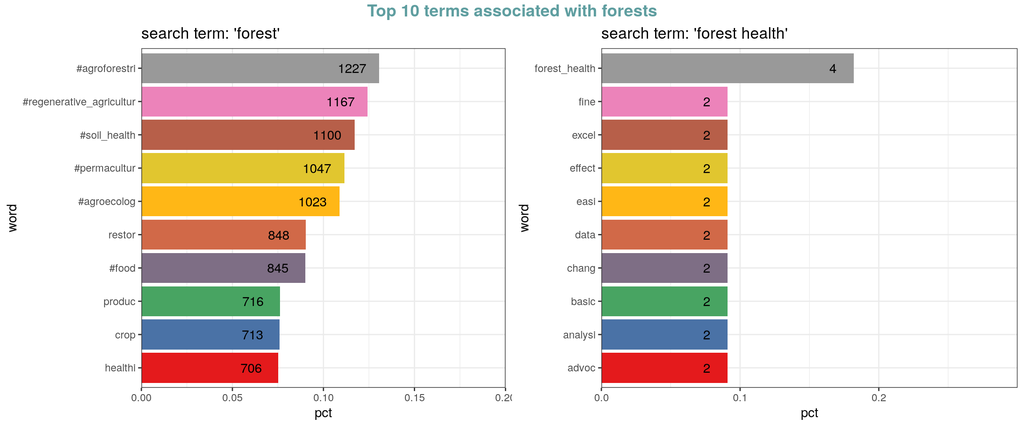

percents are relative to the top terms for each respective graph. Values in each column are the raw count of each word. The ‘forest health’ search was filtered for words counts > 1

# rangeland

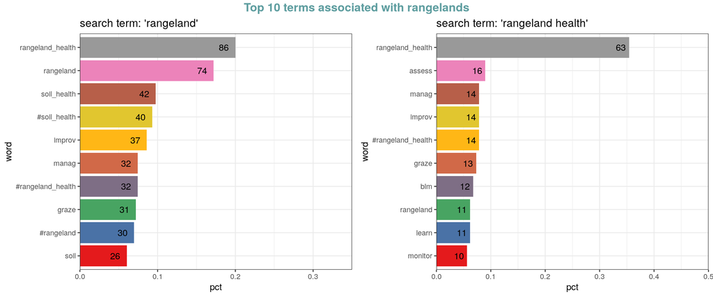

percents are relative to the top terms for each respective graph. Values in each column are the raw count of each word.